# Chapter 5: Dimensionality reduction techniques

(25.11.-2.12.2019)

- **Data wrangling**

  R script of data Wrangling exercise is available here.

  https://github.com/yufanyin/IODS-project/blob/master/create_human.R

## 5.1 Exploring the data numerically and graphically

Load necessary packages

```r
library(tidyr)
library(dplyr)
library(corrplot)
library(ggplot2)
library(GGally)
library(knitr)
library(kableExtra)
library(stringr)
library(ggfortify)
library(factoextra)
```

### 5.1.1 Reading the data

```r
human <- read.table(file = "G:/C-Open Data Science/0-191030/IODS-project-master/human_ana.txt")
```

### 5.1.2 Summaries of the variables

**(Step 1a)**

The data are the conbination of two data sets, Human Development Index (HDI) and Gender Inequality Index.

The data consist of 155 observations in 8 variables.

“Country”: country name “edu2F_edu2M”: ratio of second education of female/male “labF_labM”: ratio of labour forced female/male “exp_edu”: expected years of education “exp_life”: life expectancy at birth “GNI”: Gross National Income per capita “mat_mor”: maternal mortality ratio “ado_birth”: adolescent birth rate “F_parli”: percetange of female representatives in parliament

```r
knitr::kable(summary(human)) %>% kable_styling(bootstrap_options = "striped", position = "center", font_size = 12)
```

|  | edu2F_edu2M | labF_labM | exp_edu | exp_life | GNI | mat_mor | ado_birth | F_parli |
| --- | --- | --- | --- | --- | --- | --- | --- | --- |
|  | Min. :0.1717 | Min. :0.1857 | Min. : 5.40 | Min. :49.00 | Min. : 581 | Min. : 1.0 | Min. : 0.60 | Min. : 0.00 |
|  | 1st Qu.:0.7264 | 1st Qu.:0.5984 | 1st Qu.:11.25 | 1st Qu.:66.30 | 1st Qu.: 4198 | 1st Qu.: 11.5 | 1st Qu.: 12.65 | 1st Qu.:12.40 |
|  | Median :0.9375 | Median :0.7535 | Median :13.50 | Median :74.20 | Median : 12040 | Median : 49.0 | Median : 33.60 | Median :19.30 |
|  | Mean :0.8529 | Mean :0.7074 | Mean :13.18 | Mean :71.65 | Mean : 17628 | Mean : 149.1 | Mean : 47.16 | Mean :20.91 |
|  | 3rd Qu.:0.9968 | 3rd Qu.:0.8535 | 3rd Qu.:15.20 | 3rd Qu.:77.25 | 3rd Qu.: 24512 | 3rd Qu.: 190.0 | 3rd Qu.: 71.95 | 3rd Qu.:27.95 |
|  | Max. :1.4967 | Max. :1.0380 | Max. :20.20 | Max. :83.50 | Max. :123124 | Max. :1100.0 | Max. :204.80 | Max. :57.50 |

### 5.1.3 Graphical overview of the data

**(Step 1b)**

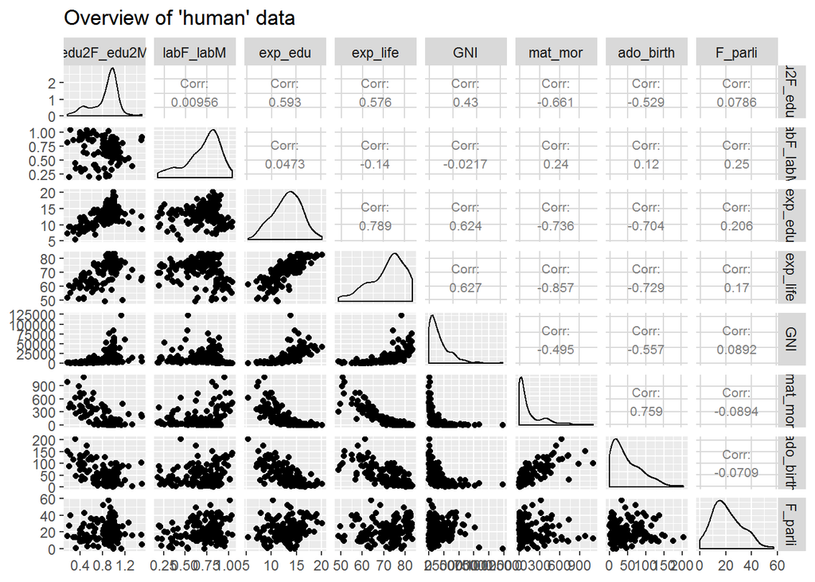

```r
ov_human <- ggpairs(human, mapping = aes(), title ="Overview of 'human' data", lower = list(combo = wrap("facethist", bins = 20)), upper = list(continuous = wrap("cor", size = 2.8)))
ov_human
```

### 5.1.4 Relationships between the variables

**(Step 1c)**

```r
cor_human <- cor(human) %>% round(digits = 2)
cor_human %>% knitr::kable(caption = "Correlation between variables") %>%
  kable_styling(bootstrap_options = "striped", full_width = FALSE, position = "center")
```

Correlation between variables

|  | edu2F_edu2M | labF_labM | exp_edu | exp_life | GNI | mat_mor | ado_birth | F_parli |
| --- | --- | --- | --- | --- | --- | --- | --- | --- |
| edu2F_edu2M | 1.00 | 0.01 | 0.59 | 0.58 | 0.43 | -0.66 | -0.53 | 0.08 |
| labF_labM | 0.01 | 1.00 | 0.05 | -0.14 | -0.02 | 0.24 | 0.12 | 0.25 |
| exp_edu | 0.59 | 0.05 | 1.00 | 0.79 | 0.62 | -0.74 | -0.70 | 0.21 |
| exp_life | 0.58 | -0.14 | 0.79 | 1.00 | 0.63 | -0.86 | -0.73 | 0.17 |
| GNI | 0.43 | -0.02 | 0.62 | 0.63 | 1.00 | -0.50 | -0.56 | 0.09 |
| mat_mor | -0.66 | 0.24 | -0.74 | -0.86 | -0.50 | 1.00 | 0.76 | -0.09 |
| ado_birth | -0.53 | 0.12 | -0.70 | -0.73 | -0.56 | 0.76 | 1.00 | -0.07 |
| F_parli | 0.08 | 0.25 | 0.21 | 0.17 | 0.09 | -0.09 | -0.07 | 1.00 |

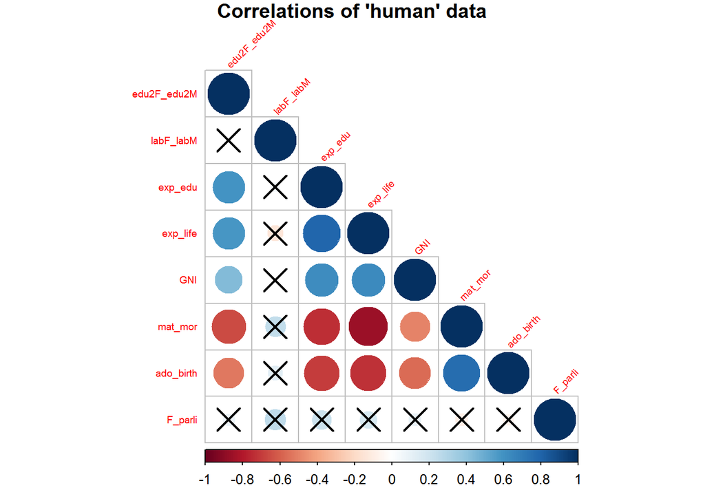

```r
p.mat <- cor.mtest(cor_human)$p
corrplot(cor_human, method="circle",  type="lower",  tl.cex = 0.6, p.mat = p.mat, sig.level = 0.01, tl.srt = 45, title="Correlations of 'human' data", mar=c(0,0,1,0))
```

Expected years of education strongly positively correlated with Live expectation and strongly negatively correlated with maternal mortality ratio. It indicated that a better education leads to a higher life expectation and contributes to a lower maternal mortality.

Another strong positive correlation was seen between adolescent birth rate and maternal mortality ratio. This may be due to high quality of medical care.

## 5.2 Principal component analysis (PCA) on non-standardized data

In PCA, the data are first transformed to a new space with equal or less number of dimensions which called the principal components. The 1st principal component captures the maximum amount of variance from the features in the original data. The 2nd principal component is orthogonal to the first and it captures the maximum amount of variability left.

### 5.2.1 Variability captured by the principal components

**(Step 2a)**

```r
pca_human <- prcomp(human)
round(pca_human$rotation[,1:2], digits = 4) %>% knitr::kable(caption = "PCA result on all variables") %>% kable_styling(bootstrap_options = "striped", full_width = FALSE, position = "center")
```

PCA result on all variables

|  | PC1 | PC2 |
| --- | --- | --- |
| edu2F_edu2M | 0.0000 | 0.0007 |
| labF_labM | 0.0000 | -0.0003 |
| exp_edu | -0.0001 | 0.0076 |
| exp_life | -0.0003 | 0.0283 |
| GNI | -1.0000 | -0.0058 |
| mat_mor | 0.0057 | -0.9916 |
| ado_birth | 0.0012 | -0.1256 |
| F_parli | -0.0001 | 0.0032 |

```r
s1 <- summary(pca_human)
pca_prc1 <- round(100 * s1$importance[2, ], digits = 3)
round(100 * s1$importance[2, 1:2], digits = 5) %>% knitr::kable(caption = "Principle components") %>% kable_styling(bootstrap_options = "striped", full_width = FALSE, position = "center")
```

Principle components

|  | x |
| --- | --- |
| PC1 | 99.99 |
| PC2 | 0.01 |

### 5.2.2 PCA Biplot displaying the observations by the first two principal components

**(Step 2b)**

The biplot displayed the observations by the first two principal components (PC1 coordinate in x-axis, PC2 coordinate in y-axis), along with arrows representing the original variables.

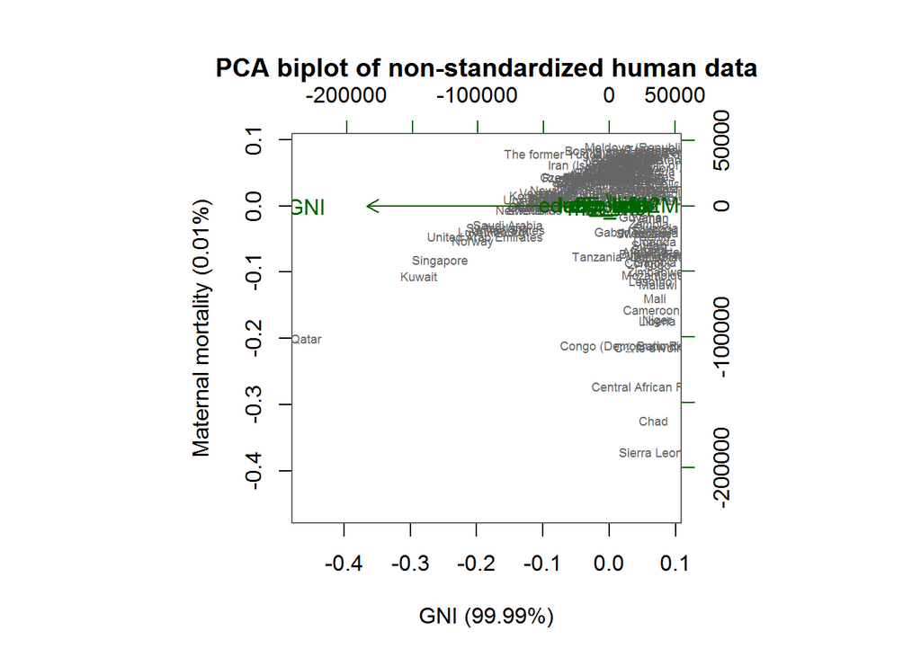

```r
pca_label1 <-  paste0("GNI (", pca_prc1[1],"%)" )
pca_label2 <-  paste0("Maternal mortality (", pca_prc1[2],"%)" )
biplot(pca_human, choices = 1:2, cex = c(0.55, 0,9), col = c("grey40", "darkgreen"), xlab = pca_label1, ylab = pca_label2, main = "PCA biplot of non-standardized human data", margin =c(0,0,5,0))
```

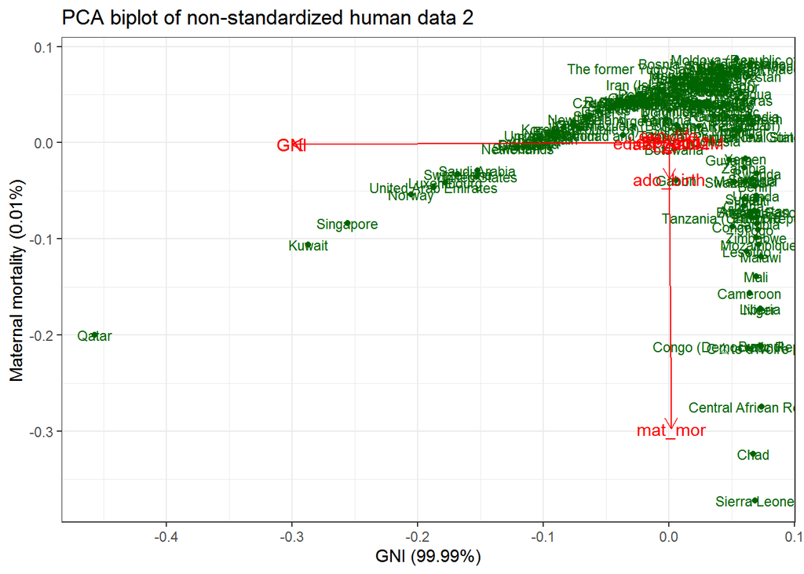

```r
autoplot(pca_human, data = human, label= TRUE, label.size = 3.0, colour = "darkgreen", loadings = TRUE, loadings.label = TRUE, loadings.colour = "red",) + ggtitle("PCA biplot of non-standardized human data 2") + xlab(paste0(pca_label1))  + ylab(paste0(pca_label2)) + theme_bw()
```

Principal component 1 (GNI) represents 99.99% of the variance of the non-standardized data. PC2 (maternal mortalility ratio) captures 0.01% of the variance. The Gross National Income per capita explains 99.99% of the principal component 1 of the data.

## 5.3 Principal component analysis (PCA) on standardized data

### 5.3.1 Scaling the data

**(Step 3a)**

The summary of the standardized data is as follows (The mean of all values is 0 and the standard diviation reaches 1).

```r
stzd_human <- scale(human)
knitr::kable(summary(stzd_human)) %>%
  kable_styling(bootstrap_options = "striped", position = "center", font_size = 11)
```

|  | edu2F_edu2M | labF_labM | exp_edu | exp_life | GNI | mat_mor | ado_birth | F_parli |
| --- | --- | --- | --- | --- | --- | --- | --- | --- |
|  | Min. :-2.8189 | Min. :-2.6247 | Min. :-2.7378 | Min. :-2.7188 | Min. :-0.9193 | Min. :-0.6992 | Min. :-1.1325 | Min. :-1.8203 |
|  | 1st Qu.:-0.5233 | 1st Qu.:-0.5484 | 1st Qu.:-0.6782 | 1st Qu.:-0.6425 | 1st Qu.:-0.7243 | 1st Qu.:-0.6496 | 1st Qu.:-0.8394 | 1st Qu.:-0.7409 |
|  | Median : 0.3503 | Median : 0.2316 | Median : 0.1140 | Median : 0.3056 | Median :-0.3013 | Median :-0.4726 | Median :-0.3298 | Median :-0.1403 |
|  | Mean : 0.0000 | Mean : 0.0000 | Mean : 0.0000 | Mean : 0.0000 | Mean : 0.0000 | Mean : 0.0000 | Mean : 0.0000 | Mean : 0.0000 |
|  | 3rd Qu.: 0.5958 | 3rd Qu.: 0.7350 | 3rd Qu.: 0.7126 | 3rd Qu.: 0.6717 | 3rd Qu.: 0.3712 | 3rd Qu.: 0.1932 | 3rd Qu.: 0.6030 | 3rd Qu.: 0.6127 |
|  | Max. : 2.6646 | Max. : 1.6632 | Max. : 2.4730 | Max. : 1.4218 | Max. : 5.6890 | Max. : 4.4899 | Max. : 3.8344 | Max. : 3.1850 |

### 5.3.2 Variability captured by the principal components

**(Step 3b)**

```r
pca_stzd_human <- prcomp(stzd_human)
round(pca_stzd_human$rotation[, 1:2], digits = 4) %>% knitr::kable(caption = "PC1 & 2 of standardized 'human' data") %>% kable_styling(bootstrap_options = "striped", full_width = FALSE, position = "center")
```

PC1 & 2 of standardized ‘human’ data

|  | PC1 | PC2 |
| --- | --- | --- |
| edu2F_edu2M | -0.3566 | 0.0380 |
| labF_labM | 0.0546 | 0.7243 |
| exp_edu | -0.4277 | 0.1394 |
| exp_life | -0.4437 | -0.0253 |
| GNI | -0.3505 | 0.0506 |
| mat_mor | 0.4370 | 0.1451 |
| ado_birth | 0.4113 | 0.0771 |
| F_parli | -0.0844 | 0.6514 |

```r
s2 <- summary(pca_stzd_human)
pca_prc2 <- round(100 * s2$importance[2, ], digits = 1)

pca_label2.1 <- paste0("Education and health (",pca_prc2[1],"%) ")
pca_label2.2 <- paste0("Female social participation (",pca_prc2[2],"%) ")

round(100 * s2$importance[2, 1:2], digits = 2) %>% knitr::kable(caption = "Principle components") %>% kable_styling(bootstrap_options = "striped", full_width = FALSE, position = "center")
```

Principle components

|  | x |
| --- | --- |
| PC1 | 53.61 |
| PC2 | 16.24 |

### 5.3.3 PCA Biplot

**(Step 3c)**

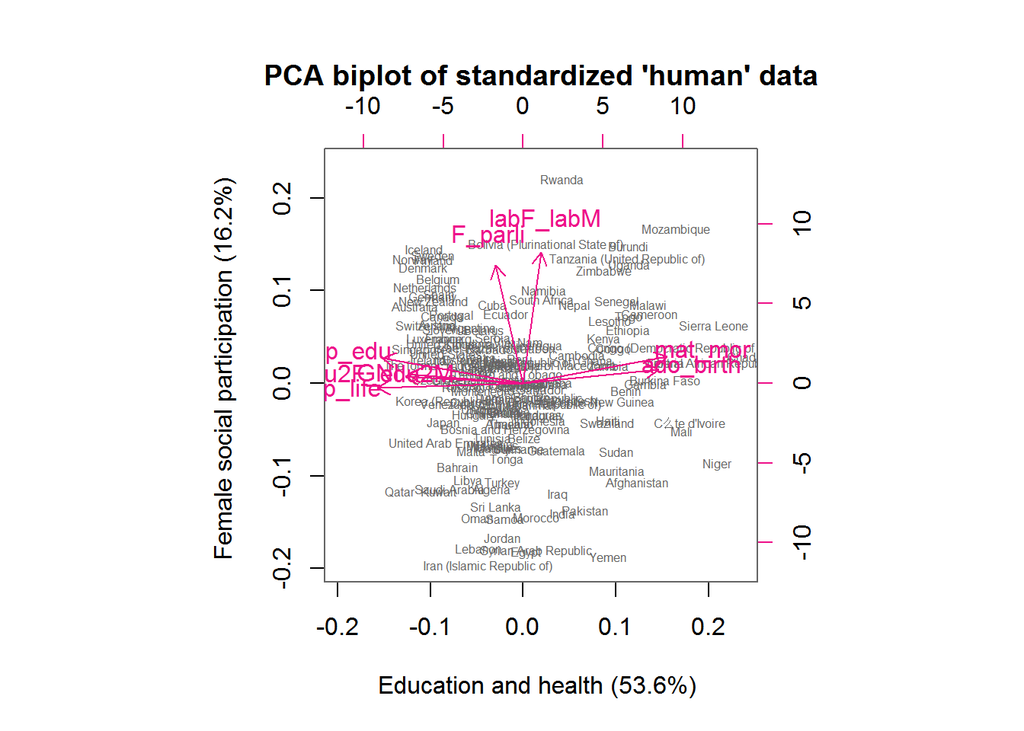

```r
biplot(pca_stzd_human, choices = 1:2, cex = c(0.5, 0,9), col = c("grey40", "deeppink2"), xlab = pca_label2.1, ylab = pca_label2.2, main = "PCA biplot of standardized 'human' data", margin =c(0,0,5,0))
```

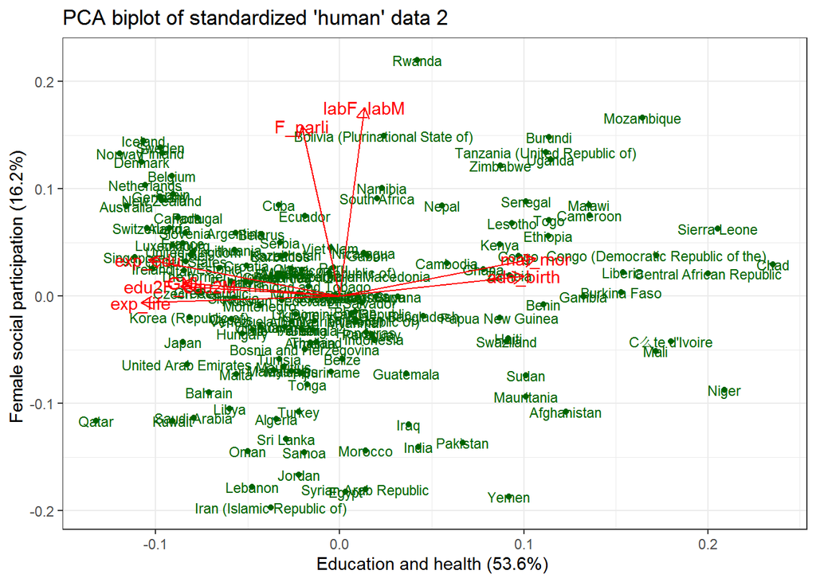

```r
autoplot(prcomp(stzd_human), data = human, colour = "darkgreen", label= TRUE, label.size = 3.0, loadings = TRUE, loadings.label = TRUE, loadings.colour = "red",) + ggtitle("PCA biplot of standardized 'human' data 2") + xlab(paste0(pca_label2.1))  + ylab(paste0(pca_label2.2)) + theme_bw()
```

### 5.3.4 Interpretations of the first two principal component dimensions

**(Step 4)**

The principal component representing 16.2% of the data variation was strongly associated with percentage of parliament representatives (“F_parli”) and ratio of labour forced female/male (“labF_labM”). So the share of of woman in labour market and in the political representatives were mostly associated with principal component 2. The variables which showed the strongest association with principal component 1 and represented 53.6% of the data variation were life expectancy (“exp_life”), expected years of education (“exp_edu”), the ratio of second education of female/male (“edu2F_edu2M”), adolescent birth rate (“ado_birth”) and maternal mortality ratio (“mat_mor”). Hence principal component 1 discribed the health and education situation in those countries.

The PCA result on between non-standardized data differed from that on standardized data. In the PCA of the non-standardized human data, the principal component 1 represents almost all varation and Gross National Income per capita is the value representing principle component 1. The PCA of standardized values looks quite different. The PC1 & PC2 values spread all over the biplot and more variables are associated to these two principal components. To perform the PCA, it is necessary to standardizing variables of obsvervations so that values become comparable. **(Before doing this exercise, I did not know why I needed to standardize first! Now I understand.)**

The angle between the arrows represents the original features of the data and can be interpreted as the correlation between these features. Small angle between the arrows means that the correlation is positive. The angle between the feature and the principal component can be interpreted as the correlation between these two components. Similarly, if the angle is small there is a positive correlation. The length of the arrows is proportional to the standard deviation of the features.

## 5.4 Multiple Correspondence Analysis (MCA)

### 5.4.1 Structure and dimensions of ‘tea’ data

**(Step 5a)**

The tea data about tea consumption behaviour were loaded from the package Factominer. The data consist of 300 observations in 36 variables.

```r
library(FactoMineR)
data(tea)
dim(tea)
```

```
## [1] 300  36
```

```r
str(tea)
```

```
## 'data.frame':    300 obs. of  36 variables:
##  $ breakfast       : Factor w/ 2 levels "breakfast","Not.breakfast": 1 1 2 2 1 2 1 2 1 1 ...
##  $ tea.time        : Factor w/ 2 levels "Not.tea time",..: 1 1 2 1 1 1 2 2 2 1 ...
##  $ evening         : Factor w/ 2 levels "evening","Not.evening": 2 2 1 2 1 2 2 1 2 1 ...
##  $ lunch           : Factor w/ 2 levels "lunch","Not.lunch": 2 2 2 2 2 2 2 2 2 2 ...
##  $ dinner          : Factor w/ 2 levels "dinner","Not.dinner": 2 2 1 1 2 1 2 2 2 2 ...
##  $ always          : Factor w/ 2 levels "always","Not.always": 2 2 2 2 1 2 2 2 2 2 ...
##  $ home            : Factor w/ 2 levels "home","Not.home": 1 1 1 1 1 1 1 1 1 1 ...
##  $ work            : Factor w/ 2 levels "Not.work","work": 1 1 2 1 1 1 1 1 1 1 ...
##  $ tearoom         : Factor w/ 2 levels "Not.tearoom",..: 1 1 1 1 1 1 1 1 1 2 ...
##  $ friends         : Factor w/ 2 levels "friends","Not.friends": 2 2 1 2 2 2 1 2 2 2 ...
##  $ resto           : Factor w/ 2 levels "Not.resto","resto": 1 1 2 1 1 1 1 1 1 1 ...
##  $ pub             : Factor w/ 2 levels "Not.pub","pub": 1 1 1 1 1 1 1 1 1 1 ...
##  $ Tea             : Factor w/ 3 levels "black","Earl Grey",..: 1 1 2 2 2 2 2 1 2 1 ...
##  $ How             : Factor w/ 4 levels "alone","lemon",..: 1 3 1 1 1 1 1 3 3 1 ...
```

[output cut: 22 more lines]

### 5.4.2 Visualization of ‘tea’ data

**(Step 5b)**

**Error in the following chunk:**

Warning: attributes are not identical across measure variables;

they will be dropped

**WHY?** The error occurred in knitting index.rmd. Everything was fine when I knitted chapter5.rmd

I had to add #### so that all the following codes would be able to display without running.

```r
# column names to keep in the dataset
#### keep_tea <- c("Tea", "How", "how", "price", "where", "lunch")
#### keep_tea

# select and create a new dataset
#### tea_time <- select(tea, one_of(keep_tea))

#### gather(tea_time) %>% ggplot(aes(value)) + facet_wrap("key", scales = "free") + geom_bar(fill = "darkblue") + theme(axis.text.x = element_text(angle = 45, hjust = 1, size = 8))
```

### 5.4.3 Multiple Correspondence Analysis and its summary

**(Step 5c)**

```r
#### mca_tea_time <- MCA(tea_time, graph = FALSE)
#### summary(mca_tea_time)
```

Visualize MCA

```r
#### plot(mca_tea_time, invisible=c("ind"), habillage = "quali")
```

### 5.4.4 MCA biplot of tea consumption behaviour

**(Step 5d)**

An individual value between 0 & 1 was added to colour the cosine-squared (cos2), a value between 0 & 1. The closer to 1, the better this value projected on the dimension.

```r
#### fviz_mca_biplot(mca_tea_time, col.ind = "cos2", col.var = "darkred", label = "var", geom =  c("point","text"), labelsize = 4, arrows = c(FALSE,TRUE)) + labs(title = "MCA of tea consumption behaviour") + theme_grey() + theme(axis.line = element_line(size = 0.5), panel.background = element_rect(fill = "gray93"))
```

### 5.4.5 MCA of reason for drinking tea

**(Step 5e)**

“sex”: Gender of tea consumers “age_Q”: Age group of tea consumers “spirituality”: Spiritual reason “healthy”: Health reason “slimming”: To lose weight or not “relaxing”: Relaxation or not

**(Same error in this chunk)**

```r
#### keep_reason <- c("sex", "age_Q", "spirituality", "healthy", "slimming", "relaxing")
#### tea_reason <- select(tea, one_of(keep_reason))

#### gather(tea_reason) %>% ggplot(aes(value)) + facet_wrap("key", scales = "free") + geom_bar(fill = "darkblue", alpha = 0.6) + theme(axis.text.x = element_text(angle = 45, hjust = 1, size = 8))
```

MCA of ‘tea_reason’ data

```r
#### mca_tea_reason <- MCA(tea_reason, graph = FALSE)
#### summary(mca_tea_reason)
```

Call: MCA(X = tea_reason, graph = FALSE)

Eigenvalues

```
                Dim.1   Dim.2   Dim.3   Dim.4   Dim.5   Dim.6
```

Variance 0.233 0.217 0.202 0.173 0.166 0.138

% of var. 15.562 14.476 13.456 11.502 11.066 9.187

Cumulative % of var. 15.562 30.039 43.495 54.997 66.063 75.251

```
                Dim.7   Dim.8   Dim.9
```

Variance 0.132 0.126 0.113

% of var. 8.833 8.393 7.523

Cumulative % of var. 84.083 92.477 100.000

Individuals (the 10 first)

```
             Dim.1    ctr   cos2    Dim.2    ctr   cos2    Dim.3
```

1 | 0.491 0.344 0.135 | 0.199 0.061 0.022 | 0.110

2 | 0.506 0.366 0.210 | 0.599 0.551 0.294 | -0.564

3 | 0.039 0.002 0.001 | 0.353 0.191 0.119 | -0.380

4 | -0.602 0.518 0.306 | -0.531 0.432 0.237 | 0.178

5 | 0.208 0.062 0.024 | -0.446 0.305 0.112 | -0.116

6 | -0.270 0.104 0.081 | -0.288 0.128 0.093 | 0.198

7 | 0.024 0.001 0.000 | -0.047 0.003 0.001 | 0.294

8 | -0.193 0.053 0.025 | 0.146 0.033 0.014 | -0.211

9 | 0.308 0.135 0.049 | -0.410 0.259 0.088 | 0.073

10 | 0.024 0.001 0.000 | -0.047 0.003 0.001 | 0.294

```
             ctr   cos2
```

1 0.020 0.007 |

2 0.526 0.261 |

3 0.239 0.138 |

4 0.052 0.027 |

5 0.022 0.008 |

6 0.065 0.044 |

7 0.143 0.054 |

8 0.074 0.030 |

9 0.009 0.003 |

10 0.143 0.054 |

Categories (the 10 first)

```
              Dim.1     ctr    cos2  v.test     Dim.2     ctr
```

F | -0.256 2.767 0.095 -5.338 | 0.220 2.198

M | 0.373 4.037 0.095 5.338 | -0.321 3.208

15-24 | -0.834 15.237 0.308 -9.593 | -0.524 6.472

25-34 | 0.681 7.619 0.139 6.437 | -0.744 9.760

35-44 | 0.018 0.003 0.000 0.121 | 0.149 0.229

45-59 | 0.692 6.948 0.122 6.043 | 0.728 8.276

+60 | -0.346 1.086 0.017 -2.282 | 1.293 16.262

Not.spirituality | 0.302 4.458 0.199 7.719 | 0.212 2.374

spirituality | -0.661 9.770 0.199 -7.719 | -0.465 5.203

healthy | -0.247 3.050 0.142 -6.525 | 0.304 4.981

```
             cos2  v.test     Dim.3     ctr    cos2  v.test
```

F 0.070 4.589 | -0.555 15.066 0.449 -11.582 |

M 0.070 -4.589 | 0.809 21.981 0.449 11.582 |

15-24 0.122 -6.030 | -0.522 6.893 0.120 -6.000 |

25-34 0.165 -7.027 | 0.983 18.367 0.289 9.294 |

35-44 0.003 1.014 | -0.261 0.750 0.010 -1.770 |

45-59 0.135 6.361 | -0.716 8.605 0.131 -6.254 |

+60 0.243 8.517 | 0.901 8.498 0.118 5.936 |

Not.spirituality 0.099 5.433 | 0.017 0.016 0.001 0.432 |

spirituality 0.099 -5.433 | -0.037 0.035 0.001 -0.432 |

healthy 0.216 8.043 | 0.179 1.853 0.075 4.730 |

Categorical variables (eta2)

```
            Dim.1 Dim.2 Dim.3
```

sex | 0.095 0.070 0.449 |

age_Q | 0.433 0.534 0.522 |

spirituality | 0.199 0.099 0.001 |

healthy | 0.142 0.216 0.075 |

slimming | 0.100 0.272 0.107 |

relaxing | 0.431 0.111 0.058 |

MCA biplot of ‘tea_reason’ data

```r
#### fviz_mca_biplot(mca_tea_reason, col.ind = "cos2", col.var = "darkred", alpha.var = "contrib", label = "var", geom =  c("point","text"), labelsize = 3.5, arrows = c(FALSE,TRUE)) + labs(title = "MCA of tea consumption reasons") + theme_grey() + theme(axis.line = element_line(size = 0.5), panel.background = element_rect(fill = "gray93"))
```

**(Step 5f)**

**Note:** PCA and MCA biplot help to visualize results much better than doing in SPSS. Wrting codes in R is a bit more abstract but it is worth learning.